# Zillow Home Values

Ben Pfeffer

March 20, 2020

# Introduction

In this project we will build a few models that attempt to predict the Zillow Zestimate home value of houses in the city of Los Angeles. The code for this project is [on GitHub](https://github.com/ben-pfeffer/zillow-home-values)

We begin with a CSV of all the home addresses in the city. This file is provided publically by the city of Los Angeles. You can view or download it [here](https://data.lacity.org/A-Well-Run-City/Addresses-in-the-City-of-Los-Angeles/4ca8-mxuh).

We will clean this data and use it to query the Zillow API for information on the homes. Since it is not feasable to query Zillow for every address in LA, we take a random sample from the list of addresses. We use the addresses in that sample to query the Zillow API. Information on homes that have at least a Zillow Zestimate value are written to a CSV file.

The Zillow API will give us data on home’s Zestimate value, its tax assessment value, and many properties of the home including square footage, number of bedrooms and bathrooms, year built, and home type (ie single family, duplex, or condo). We will use these factors to train a model that predicts a home’s Zillow Zestimate value.

We take the information written to the CSV and use it to create three models that attempt to predict Zillow’s Zestimate home value. In this project I use a linear regression, an elastic net regression, and a boosted tree model.

Of the three models created, the boosted tree outperforms the regression models. There may be room for further improvement with more processing power and time, larger sample size, or collecting different variables from other sources.

# Data Prep

Our first step is to read in the home addresses file and drop the columns we don’t need for this analysis

```r
address.data <- readr::read_csv('LA-addresses.csv', col_types = cols(UNIT_RANGE = col_character())) %>%
  select(HSE_NBR:ZIP_CD)
```

The variables we keep from the LA addresses data set are:  
* `HSE_NBR` - House Number  
* `HSE_FRAC_NBR` - House Number Fraction  
* `HSE_DIR_CD` - House Direction Code. The street direction * `STR_NM` - Street Name  
* `STR_SFX_CD` - Street Suffix  
* `STR_SFX_DIR_CD` - Street Suffix Direction  
* `UNIT_RANGE` - Unit Range  
* `ZIP_CD` - Zip Code

Below is the start of the data we are provided by the City of Los Angeles:

```
## # A tibble: 1,003,783 x 8
##    HSE_NBR HSE_FRAC_NBR HSE_DIR_CD STR_NM STR_SFX_CD STR_SFX_DIR_CD UNIT_RANGE
##      <dbl> <chr>        <chr>      <chr>  <chr>      <chr>          <chr>
##  1    1769 <NA>         N          IVAR   AVE        <NA>           <NA>
##  2     260 <NA>         S          6TH    AVE        <NA>           <NA>
##  3    8802 <NA>         S          BELFO~ AVE        <NA>           <NA>
##  4    4610 <NA>         W          MAUBE~ AVE        <NA>           <NA>
##  5    8802 1/2          S          BELFO~ AVE        <NA>           <NA>
##  6    8320 <NA>         N          CHELS~ LANE       <NA>           <NA>
##  7    2031 <NA>         N          CHERE~ AVE        <NA>           <NA>
##  8    9039 <NA>         W          CRESTA DR         <NA>           <NA>
##  9    5500 <NA>         S          FORTU~ ST         <NA>           <NA>
## 10    5821 <NA>         N          YOLAN~ AVE        <NA>           <NA>
## # ... with 1,003,773 more rows, and 1 more variable: ZIP_CD <dbl>
```

Since the Zillow API only allows 5000 queries per day, we will select a random sample of the 1 million homes. We set our sample size to 5000.

```r
sample.size <- 5000

# get random sample of addresses to query from zillow
sample <- sample(1:nrow(address.data), size = sample.size)
address.sample <- address.data[sample, ]
```

The Zillow API wants 2 variables: an `address` (eg. 123 Main St.) and a `city/state/zip` variable (eg. Los Angeles, CA 12345).

Our next step is to clean the `address.sample` into the format required by the Zillow API.

```r
# clean up address and city/state/zip data to match format expected by zillow API
address.sample <- mutate(address.sample, clean.address = paste0(HSE_NBR, ' ',
                                                      ifelse(!is.na(HSE_FRAC_NBR),
                                                             HSE_FRAC_NBR, ''), ' ',
                                                      STR_NM, ' ', STR_SFX_CD, ' ',
                                                      ifelse(!is.na(STR_SFX_DIR_CD),
                                                             STR_SFX_DIR_CD, ''))) %>%
                mutate(clean.citystatezip = paste('Los Angeles, CA', ZIP_CD)) %>%
                select(clean.address, clean.citystatezip)

address.sample
```

```
## # A tibble: 5,000 x 2
##    clean.address             clean.citystatezip
##    <chr>                     <chr>
##  1 "6809  QUINTON LANE "     Los Angeles, CA 91042
##  2 "326  BRONSON AVE "       Los Angeles, CA 90004
##  3 "1621 1/2 CAHUENGA BLVD " Los Angeles, CA 90028
##  4 "231  LUCAS AVE "         Los Angeles, CA 90026
##  5 "7408  OSTROM AVE "       Los Angeles, CA 91406
##  6 "13665  WOODCOCK AVE "    Los Angeles, CA 91342
##  7 "2342  ELMGROVE ST "      Los Angeles, CA 90031
##  8 "300  RENO ST "           Los Angeles, CA 90057
##  9 "1826  WASHINGTON WAY "   Los Angeles, CA 90291
## 10 "215  CATALINA ST "       Los Angeles, CA 90004
## # ... with 4,990 more rows
```

The code above pastes the columnar data together in the correct order. For variables that are not always present (House Fraction Number and Street Directional Suffix) we conditionally input them only when they are present.

**One note about this setup:** we do not need to specify a unit for the multifamily addresses. The Zillow API returns information on all units at a address when no unit is supplied, and the code that follows will return the information for the first unit that Zillow gives us. Consequentially, multifamily units may be underrepresented in the sample as a percentage of total *dwellings*–but not as a percentage of total *buildings*. The sample may also be slightly unrepresentative if the first unit in a multifamily building tends to be larger or smaller than the other units. However, for the purposes of this project I think our method is sufficient for building a predictive model.

# Gathering Zillow Data

We load in 3 custom functions that we will use to build a dataframe from the Zillow API calls.

```r
# adds variable to our list of variables, or adds NA if zillow does not have a value for that variable
appendVariable <- function(variable, vector) {
  x <- ifelse(is_empty(variable), NA, variable)
  return(append(vector, x))
}

# adds all variables to our varibable list, or adds NA if no information is provided
addAllVariables <- function(zillow.data, variable.list) {

  # get variables from zillow's XML formatted data
  street.name.num    <- unlist(zillow.data$response[['results']][['result']]
                              [['address']][['street']])[['children.text.value']]
  zipcode            <- unlist(zillow.data$response[['results']][['result']]
                              [['address']][['zipcode']])[['children.text.value']]
  cityy              <- unlist(zillow.data$response[['results']][['result']]
                              [['address']][['city']])[['children.text.value']]
  usecode            <- unlist(zillow.data$response[['results']][['result']]
                               [['useCode']])[['children.text.value']]
  region.nam         <- unlist(zillow.data$response[['results']][['result']]
                               [['localRealEstate']][['region']])[['attributes.name']]
  region.typ         <- unlist(zillow.data$response[['results']][['result']]
                               [['localRealEstate']][['region']])[['attributes.type']]
  lsd                <- unlist(zillow.data$response[['results']][['result']]
                               [['lastSoldDate']])[['children.text.value']]
  tax.assessment.yr  <- as.numeric(unlist(zillow.data$response[['results']][['result']]
                                          [['taxAssessmentYear']])[['children.text.value']])
  tax.assessment.val <- as.numeric(unlist(zillow.data$response[['results']][['result']]
                                          [['taxAssessment']])[['children.text.value']])
  yr.built           <- as.numeric(unlist(zillow.data$response[['results']][['result']]
                                          [['yearBuilt']])[['children.text.value']])
  lotsize            <- as.numeric(unlist(zillow.data$response[['results']][['result']]
                                          [['lotSizeSqFt']])[['children.text.value']])
  finishedsqft       <- as.numeric(unlist(zillow.data$response[['results']][['result']]
                                          [['finishedSqFt']])[['children.text.value']])
  bathrms            <- as.numeric(unlist(zillow.data$response[['results']][['result']]
                                          [['bathrooms']])[['children.text.value']])
  bedrms             <- as.numeric(unlist(zillow.data$response[['results']][['result']]
                                          [['bedrooms']])[['children.text.value']])
  lsp                <- as.numeric(unlist(zillow.data$response[['results']][['result']]
                                          [['lastSoldPrice']])[['children.text.value']])
  # the zindex value is a neighborhood average price
  zindex             <- as.numeric(gsub(',', '', unlist(zillow.data$response[['results']]
                                                        [['result']][['localRealEstate']]
                                                        [['region']][['zindexValue']])
                                        [['children.text.value']])) # gsub() to remove commas

  # for each variable above, append variable value to appropriate vector,
  # or appends NA if value is missing
  variable.list$street.name.and.number <- appendVariable(street.name.num, variable.list$street.name.and.number)
  variable.list$zip.code               <- appendVariable(zipcode, variable.list$zip.code)
  variable.list$city                   <- appendVariable(cityy, variable.list$city)
  variable.list$use.code               <- appendVariable(usecode, variable.list$use.code)
  variable.list$tax.assessment.year    <- appendVariable(tax.assessment.yr,
                                                         variable.list$tax.assessment.year)
  variable.list$tax.assessment.value   <- appendVariable(tax.assessment.val,
                                                         variable.list$tax.assessment.value)
  variable.list$year.built             <- appendVariable(yr.built, variable.list$year.built)
  variable.list$lot.size               <- appendVariable(lotsize, variable.list$lot.size)
  variable.list$finished.sqft          <- appendVariable(finishedsqft, variable.list$finished.sqft)
  variable.list$bathrooms              <- appendVariable(bathrms, variable.list$bathrooms)
  variable.list$bedrooms               <- appendVariable(bedrms, variable.list$bedrooms)
  variable.list$region.name            <- appendVariable(region.nam, variable.list$region.name)
  variable.list$region.type            <- appendVariable(region.typ, variable.list$region.type)
  variable.list$last.sold.date         <- appendVariable(lsd, variable.list$last.sold.date)
  variable.list$last.sold.price        <- appendVariable(lsp, variable.list$last.sold.price)
  variable.list$zindex.value           <- appendVariable(zindex, variable.list$zindex.value)
  # the zindex.value is a neighborhood average price

  return(variable.list)
}

# main function for the data collection portion of this project
# for a data frame of addresses, query zillow for information and
# if a zestimate is present, add data to output
# outputs a data frame
buildZillowTable <- function(sample, key) {

  # initialize an empty vector for each variable and put all vectors in a list
  variable.list <- list(zestimate.amount       = numeric(),
                        street.name.and.number = character(),
                        zip.code               = character(),
                        city                   = character(),
                        use.code               = character(),
                        tax.assessment.year    = numeric(),
                        tax.assessment.value   = numeric(),
                        year.built             = numeric(),
                        lot.size               = numeric(),
                        finished.sqft          = numeric(),
                        bathrooms              = numeric(),
                        bedrooms               = numeric(),
                        region.name            = character(),
                        region.type            = character(),
                        last.sold.date         = character(),
                        last.sold.price        = numeric(),
                        zindex.value           = numeric()
                        # the zindex.value is a neighborhood average price
                        )

  # query zillow for each address in sample
  # typically we would use an apply() function rather than a for loop for the added speed,
  # but the Zillow API does not allow for more than one call at a time
  # using an apply() function would give an error in this case
  for (i in 1:nrow(address.sample)) {
      zillow.data <- ZillowR::GetDeepSearchResults(address = address.sample$clean.address[i],
                                          citystatezip = address.sample$clean.citystatezip[i],
                                          zws_id = key)

      # check zestimate. sometimes the zestimate is missing, sometimes it returns an error
      zestimate <- try(as.numeric(unlist(zillow.data$response[['results']][['result']]
                                         [['zestimate']][['amount']])
                                  [['children.text.value']]), silent = TRUE)

      # if zestimate is empty or returns an error, do not record any information for this address.
      # Move to next iteration instead
      if('try-error' %in% class(zestimate)) next
      if(is_empty(zestimate)) next

      # if zestimate exsts, add it to our list and and add values for all other variables
      else {
        variable.list$zestimate.amount <- appendVariable(zestimate, variable.list$zestimate.amount)
        variable.list <- addAllVariables(zillow.data, variable.list)
    }
  }

  # when all sample has been processed, combine vectors into data frame
  df <- as.data.frame(variable.list)
  return(df)
}
```

With these functions we are ready to build a data frame from the Zillow API. Once it is built, we write the data to 2 CSV files. The first file is a new CSV file with the information we just gathered. The second is a ‘Master List’ CSV file that we append to. By appending every time we run the script over multiple days, we are able to construct a larger dataset than we would have been able to in one day (remember, the Zillow API limits us to 5000 queries per day).

```r
df <- buildZillowTable(address.sample, key)

# write data frame to csvs
write_csv(df, 'LAzillowSample.csv')
write_csv(df, 'LABigSample.csv', append = TRUE)
```

# Exploratory Data Analysis

We load in a data set containing three days worth of Zillow API queries made in the above manner. After cleaning the data into the proper format, we look at the structure of the data.

```r
home.data <- read_csv('LABigSample.csv')

# clean data set into correct format
home.data <- home.data %>% mutate(city = as.factor(city),
                                  zip.code = as.factor(zip.code),
                                  use.code = as.factor(use.code),
                                  tax.assessment.year = as.factor(tax.assessment.year),
                                  region.name = as.factor(region.name),
                                  region.type = as.factor(region.type),
                                  last.sold.date = as.Date(last.sold.date, '%m/%d/%Y'))
str(home.data)
```

```
## Classes 'spec_tbl_df', 'tbl_df', 'tbl' and 'data.frame': 8191 obs. of  17 variables:
##  $ zestimate.amount      : num  1288171 595194 740497 356044 483028 ...
##  $ street.name.and.number: chr  "836 Kodak Dr" "505 W 102nd St" "1411 W 213th St" "9305 Croesus Ave" ...
##  $ zip.code              : Factor w/ 109 levels "90001","90002",..: 22 38 68 2 72 35 96 97 106 71 ...
##  $ city                  : Factor w/ 59 levels "Arleta","Beverly Hills",..: 15 15 46 15 56 15 38 27 40 15 ...
##  $ use.code              : Factor w/ 10 levels "Condominium",..: 2 5 8 8 8 8 8 8 8 8 ...
##  $ tax.assessment.year   : Factor w/ 1 level "2019": 1 1 1 1 1 1 1 1 1 1 ...
##  $ tax.assessment.value  : num  438374 499392 94014 106450 43238 ...
##  $ year.built            : num  1966 1943 1972 1952 1939 ...
##  $ lot.size              : num  3324 5749 5004 3376 6500 ...
##  $ finished.sqft         : num  2322 1920 1910 741 1072 ...
##  $ bathrooms             : num  4 NA 3 1 1 1 1 2 5 3 ...
##  $ bedrooms              : num  4 0 4 2 3 2 2 3 5 4 ...
##  $ region.name           : Factor w/ 112 levels "Adams-Normandie",..: 82 84 37 99 110 25 81 69 86 78 ...
##  $ region.type           : Factor w/ 2 levels "city","neighborhood": 2 2 2 2 2 2 2 2 2 2 ...
##  $ last.sold.date        : Date, format: "2000-10-03" "2016-08-31" ...
##  $ last.sold.price       : num  255500 480000 NA 92000 NA ...
##  $ zindex.value          : num  991200 429200 513600 322300 423700 ...
```

**Some interesting notes from this table:** `region.name` seems to be much more granular than `city`, with 112 levels versus `city`’s 59 levels. The granularity of `zip.code` is close to that of `region.name` (109 levels vs 112 levels). The `tax.assessment.year` variable has only one value (2019). We will drop this column later as it does not provide our model with any useful information.

Now let’s look at the correlations between our numeric variables

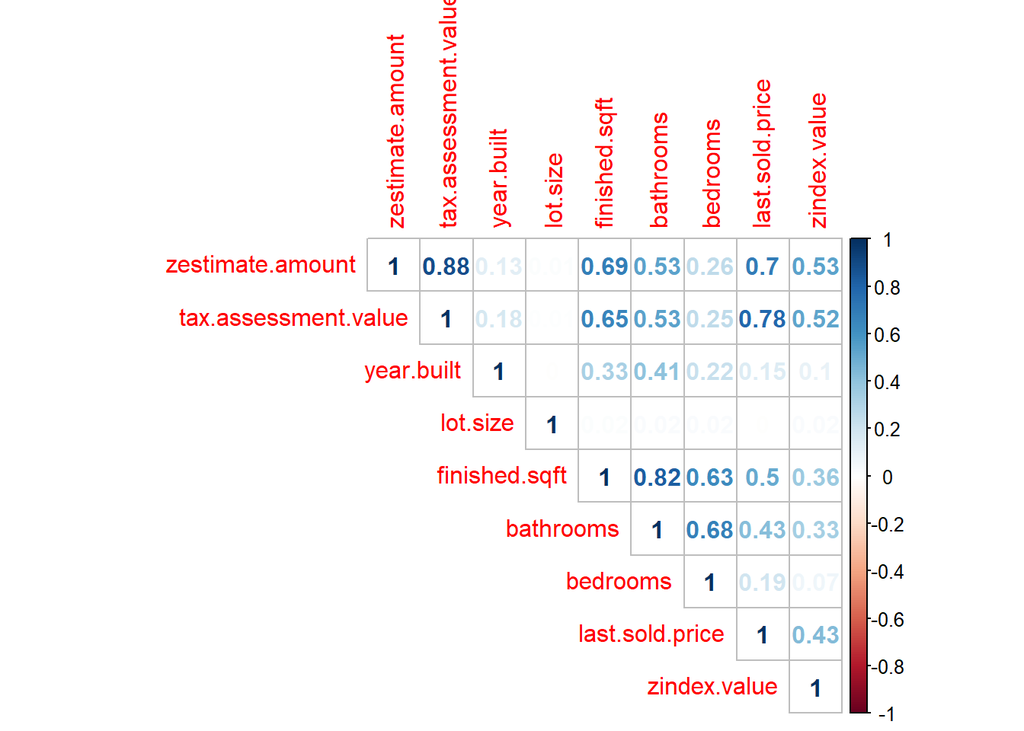

Let’s take a look at the scatterplot of the variable most strongly correlated with zestimate amount, `tax.assessment.value`.

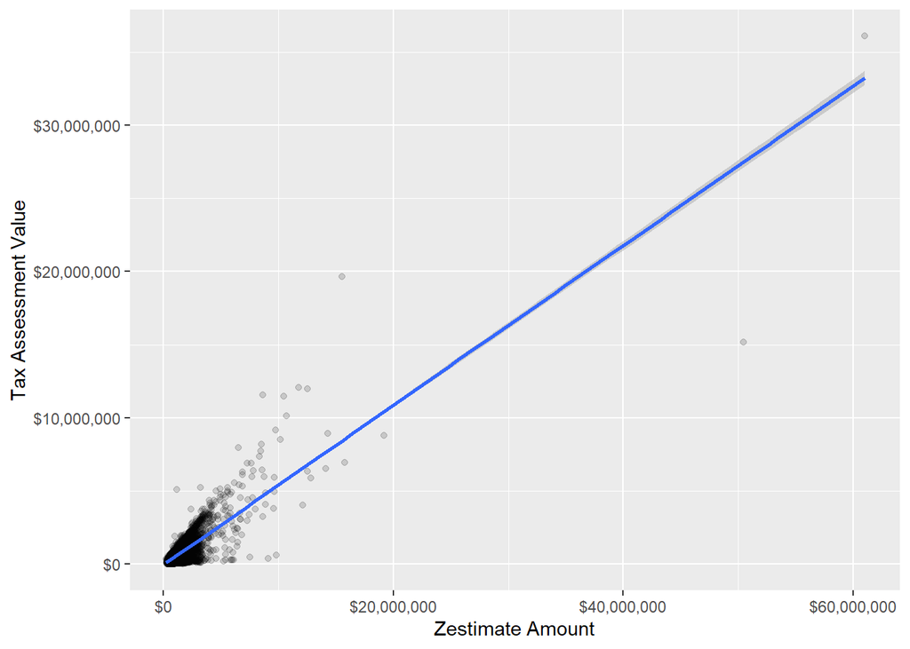

We should zoom in on the data clustered together at the more typical home values.

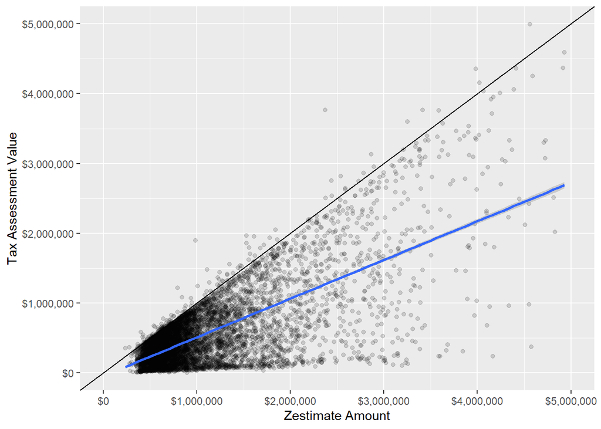

I have added the y=x line (in black) for reference. Notice that the `tax.assessment.value` is almost always less than the `zestimate.amount`. This is probably due to the infamous California [Proposition 13](https://en.wikipedia.org/wiki/1978_California_Proposition_13), which limits the taxable value of a home to the purchase price plus no more than a 2% annual increase. Consequently, people who have owned their homes for a long time pay tax at a rate that is much lower than the market value. For this reason, although `tax.assessment.value` is strongly correlated with `zeestimate.amount`, it is not going to give us an easy answer.

# Data Cleaning

Before we build our model we need to deal with the missing data points and the sparse classes within our data set.

## Missing Data

First we take care of the missing data. We calculate the total number of rows that have any missing data, and the total amount of each column that is missing.

```
## [1] "36.3% of our data has a missing value"
```

```
##       zestimate.amount street.name.and.number               zip.code
##                   0.00                   0.00                   0.00
##                   city               use.code    tax.assessment.year
##                   0.00                   0.00                   3.86
##   tax.assessment.value             year.built               lot.size
##                   3.93                   2.39                   3.13
##          finished.sqft              bathrooms               bedrooms
##                   1.38                   1.78                   0.48
##            region.name            region.type         last.sold.date
##                   0.00                   0.00                  32.78
##        last.sold.price           zindex.value
##                  32.78                   2.82
```

We can see that the `last.sold.date` and `last.sold.price` variables are both missing 32% of their entries. This high percentage, and the nature of the data (even if we were to impute these values, it’s unclear what our best guess about a date and price for a transaction that never occured would even mean) make imputation a bad idea. For these reasons, we drop these columns from our analysis along with the `tax.assessment.year` variable with only one level.

After dropping the unneeded columns, we split the data into two parts: our response variable and the rest of the data. That way, when we impute missing values, we are sure that the response variable is not being used in the imputation.

```r
# drop last.sold columns from data
home.data <- home.data %>% select(-c(last.sold.date, last.sold.price, tax.assessment.year))

# split our response variable from the rest of home.data
# so that it is not used to impute missing values
zestimates <- home.data %>% select(zestimate.amount)
home.data <- home.data %>% select(-zestimate.amount)
```

Now we are ready to impute values to our missing data. None of our categorical variables have missing values. If they did we would create a `missing` category for those variables. For the numerical variables we use the `mice` package to impute values. We use the `mice` package’s random forest imputation method.

```r
imputed <- mice::mice(home.data, method='rf', m=5, maxit = 1, seed = 123)
home.data <- complete(imputed, 1)

# stitch zestimates back onto the home.data dataset after imputation
home.data <- home.data %>% mutate('zestimate.amount' = zestimates$zestimate.amount)
```

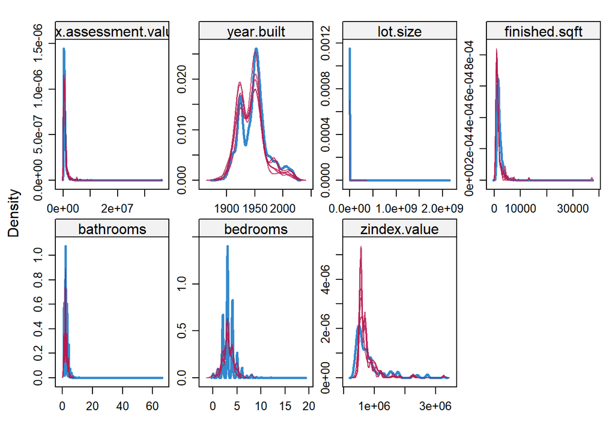

```r
mice::densityplot(imputed)
```

The imputed values (magenta) seem to match the distributions of the actual data (blue) fairly well. The `zindex.value` may be somewhat overrespresented on the lower end of the distribution, but overall it looks like the imputation went very smoothly. We are ready to begin building our models.

## Sparse Classes

We need to check our factor levels to make sure no level is too sparse. We want to have at least two instances of each factor level so that we have at least one instance of each level in both our test and training data sets. Let’s look at the `use.code` factor first.

```r
home.data %>% group_by(use.code) %>%
  summarize(no_rows = length(use.code)) %>%
  arrange(no_rows)
```

```
## # A tibble: 10 x 2
##    use.code         no_rows
##    <fct>              <int>
##  1 MultiFamily5Plus       1
##  2 Miscellaneous          4
##  3 Mobile                 4
##  4 Townhouse             71
##  5 Quadruplex           131
##  6 Triplex              140
##  7 Condominium          287
##  8 Duplex               440
##  9 MultiFamily2To4      444
## 10 SingleFamily        6669
```

We will have to remove the record with the`MultiFamily5Plus` `use.code`. Then we check `region.name`.

```r
home.data <- home.data[!home.data$use.code %in% 'MultiFamily5Plus', ]

home.data %>% group_by(region.name) %>%
  summarize(no_rows = length(region.name)) %>%
  arrange(no_rows)
```

```
## # A tibble: 112 x 2
##    region.name           no_rows
##    <fct>                   <int>
##  1 Beverly Hills Gateway       1
##  2 Canyon Country              1
##  3 Chinatown                   1
##  4 East Los Angeles            1
##  5 El Miradero                 1
##  6 Elysian Park                1
##  7 West Carson                 1
##  8 Ladera Heights              2
##  9 MacArthur Park              2
## 10 McLaughlin                  2
## # ... with 102 more rows
```

We delete the sparse factor classes from `region.name`. We do the same thing for the `zip.code` and `city` variables as well, renaming cities where there are encoding errors and then deleting the sparse classes. I have performed a check on every other factor class in this data set, but I omit the code from this report for conciseness sake. The printouts for much of this work have been omitted for conciseness sake.

```r
home.data <- home.data[!home.data$region.name %in% c('Beverly Hills Gateway', 'Canyon Country',
                                                     'Chinatown', 'East Los Angeles',
                                                     'El Miradero', 'Elysian Park', 'West Carson'), ]

# recode the obvious mis-casings to the correct case
home.data <- home.data %>% mutate(city = fct_recode(city, 'Los Angeles' = 'Los Angeles CA',
                                                    'North Hills' = 'North hills',
                                                    'North Hollywood' = 'North hollywood',
                                                    'Playa Del Rey' = 'Playa del rey',
                                                    'West Hills' = 'WEST HILLS',
                                                    'North Hollywood' = 'N Hollywood',
                                                    'San Pedro' = 'San pedro',
                                                    'Woodland Hills' = 'Woodland hills'))

# remove the sparse cities
home.data <- home.data[!home.data$city %in% c('Eagle Rock', 'Hollywood', 'Lake Balboa',
                                              'Lake View Terrace', 'Shadow Hills',
                                              'Westchester') ,]
# remove the sparse zip code
home.data <- home.data[!home.data$zip.code %in% '90010', ]
```

Now that the dataset has been built, we save it as CSV file here for easy loading later, and clear the memory.

```r
write_csv(home.data, 'home-data.csv')

# clear global environment for memory
rm(list = ls())
```

# Constructing the Models

```r
# first load the cached CSV data file
home.data <- read_csv('home-data.csv')
```

To begin, we split the data set into training (80%) and testing (20%) sets. We drop the `street.name.and.number` variable to prevent overfitting. To partition the data we use the caret `createDataPartition` funciton rather than the `sample` function because caret can automatically stratify the data along the `region.name` variable, ensuring we have at least one instance of each `region.name` in our training and test sets. This is necessary for ensuring we have at least one sample of each class in both the testing and training sets.

```r
set.seed(44)
# partition data along region.name for both datasets
train <- caret::createDataPartition(home.data$region.name, p = 0.8, list = FALSE)

# create test and training sets for home.data
train.set <- home.data[train, ] %>% select(-street.name.and.number)
test.set <- home.data[-train, ] %>% select(-street.name.and.number)
```

Our`home.data` dataset has 6585 observations in the training set and 1591 in the test set.

## Linear Regression Model

```r
# fit full linear models for both data sets
linear.fit.all <- lm(zestimate.amount ~ ., data = train.set)

# show most important variables
variable.importance <- caret::varImp(linear.fit.all) %>%
  rownames_to_column(var = 'Variable') %>%
  arrange(desc(Overall))

head(variable.importance, n = 20)
```

```
##                       Variable   Overall
## 1         tax.assessment.value 75.601160
## 2                finished.sqft 32.244468
## 3                   year.built  9.314792
## 4                     bedrooms  7.014684
## 5          region.nameSawtelle  5.177085
## 6         region.nameMar Vista  4.526084
## 7          region.nameWestwood  4.333109
## 8  region.nameWest Los Angeles  4.114722
## 9     region.nameMid City West  4.001085
## 10          region.nameDel Rey  3.987955
## 11            region.namePalms  3.975104
## 12        region.nameBrentwood  3.935881
## 13          region.nameBel Air  3.773422
## 14      region.nameBeverlywood  3.751188
## 15    region.nameCheviot Hills  3.652192
## 16            citySanta Monica  3.428163
## 17   region.namePico-Robertson  3.281431
## 18        region.nameCrestview  3.281251
## 19     region.nameCentury City  3.265251
## 20         region.nameMid City  3.247114
```

We see that the most useful variables to the model are `tax.assessment.value`, `finished.sqft`, `year.built`, and `bedrooms`. We will build a regression model using automated backward feature selection to get a baseline model to compare to more sophisticated models.

```r
linear.fit <- MASS::stepAIC(linear.fit.all, direction = 'backward', trace=FALSE)
```

We compare the Root MSE of both models on the test data sets to compare their performance.

```r
findRootMSE <- function(fit, data) {
  pred <- predict(fit, newdata = data)
  return(sqrt(sum((pred - data$zestimate.amount)^2)/nrow(data)))
}

c('Test Error' = findRootMSE(linear.fit, test.set),
                  'Training Error' = findRootMSE(linear.fit, train.set))
```

```
##     Test Error Training Error
##       634043.4       639949.7
```

We will use the `linear.fit` model as our baseline comparison model against an elastic net model and a boosted tree model.

## Elastic Net Model

An elastic net model combines ridge regression (which uses L2 regularization to penalize regression coefficients far from zero) with LASSO regression (which uses L1 regularization to penalize coefficients far from zero and performs a version of feature selection but automatically setting coefficients to zero). The goal is to decrease the variance of an Ordinary Least Squares regression model by allowing for some added bias.

For the elastic net model we use the `caret` package to tune the alpha hyperparameter, while the `glmnet` package tunes the lambda hyperparameter.

```r
# Set training control
# we test each model with 10 fold cross validation repeated 3 times
trainCtrl <- caret::trainControl(method = 'repeatedcv', number = 10, repeats = 3)

# Train the model
elastic.net.fit <- caret::train(zestimate.amount ~ .,
                           data = train.set,
                           method = "glmnet",
                           preProcess = c("center", "scale"),
                           tuneLength = 25,
                           trControl = trainCtrl)
```

Let’s compare the Root MSE of the elastic net model to the Root MSE of the regular regression model.

```r
findRootMSE(elastic.net.fit, test.set)
```

```
## [1] 571304.4
```

```
## [1] "The elastic net model has a Root MSE that is 9.9% less than the linear regression model with backward feature selection."
```

The elastic net model is an improvement over the ordinary least squares model, but I bet we can do better with a tree-based model.

## Boosted Tree Model

```r
# We use the same trainControl as in the Elastic Net model (10-fold CV repeated 3 times)

# we use tuneGrid to test all specified combinations of our 4 hyperparameters
tgrid <- expand.grid(n.trees = c(100, 200, 300, 400, 500, 600, 800, 1000,
                                 1500, 2000, 2500, 3000, 3500, 4000),
                            interaction.depth = c(4, 6),
                            shrinkage = c(.01, .02, .05),
                            n.minobsinnode = c(3, 4))

# use capture.output to suppress tons of unwanted
# printing output lines for the boosted tree model.
# the tree trains as normal
# we train one tree with all for each dataset with all available variables
data.dump <- capture.output(boosted.tree.fit <-
                              caret::train(zestimate.amount ~ use.code + tax.assessment.value +
                                             year.built + finished.sqft + bedrooms + region.name +
                                             zindex.value,
                                           data = train.set,
                                           method = 'gbm',
                                           trControl = trainCtrl,
                                           preProcess = c('center', 'scale'),
                                           tuneGrid = tgrid))
```

```r
# now we plot the tree fits to visualize how they are performing
boosted.tree.fit$bestTune
```

```
##    n.trees interaction.depth shrinkage n.minobsinnode
## 41    3500                 6      0.01              3
```

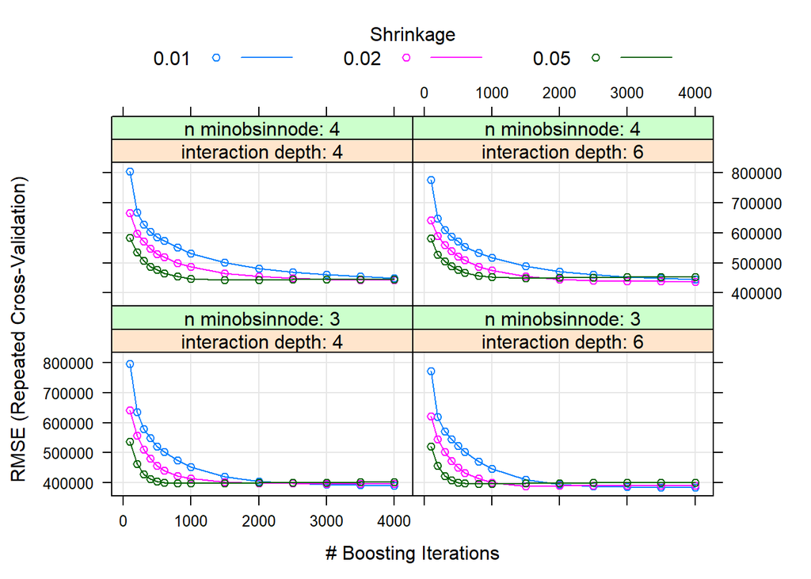

```r
plot(boosted.tree.fit)
```

```r
c('Test RMSE' = findRootMSE(boosted.tree.fit, test.set))
```

```
## Test RMSE
##  409945.7
```

```r
RMSE.improvement.percent <- (findRootMSE(linear.fit, test.set) - findRootMSE(boosted.tree.fit, test.set)) /
  findRootMSE(linear.fit, test.set) * 100

print(paste0('The boosted tree model has a RMSE that is ', round(RMSE.improvement.percent,2), '% less than the linear regression model with backward feature selection.'))
```

```
## [1] "The boosted tree model has a RMSE that is 35.34% less than the linear regression model with backward feature selection."
```

Now we compare the results of our three models.

```r
findRootMSE(linear.fit, test.set)
```

```
## [1] 634043.4
```

```r
findRootMSE(elastic.net.fit, test.set)
```

```
## [1] 571304.4
```

```r
findRootMSE(boosted.tree.fit, test.set)
```

```
## [1] 409945.7
```

As expected, the boosted tree model outperformed the linear regression model and the elastic net model.

# Conclusion

The best model we were able to create has a root mean squared error of about $410,000. That means that the mean distance from our predicted Zestimate value to the actual Zestimate value is more than $400,000. For comparison, look at the summary data for the `zestimate.amount` column:

```
##     Min.  1st Qu.   Median     Mean  3rd Qu.     Max.
##   112353   597374   776182  1114708  1241456 61013558
```

With a median of about $776,000, the root MSE is about 53% of the median value. I think there is still room for improvement here. Perhaps with more processing power and time, collecting different variables, or a larger sample size we could come up with a model that performs better, and gives us predictions closer to Zillow’s.

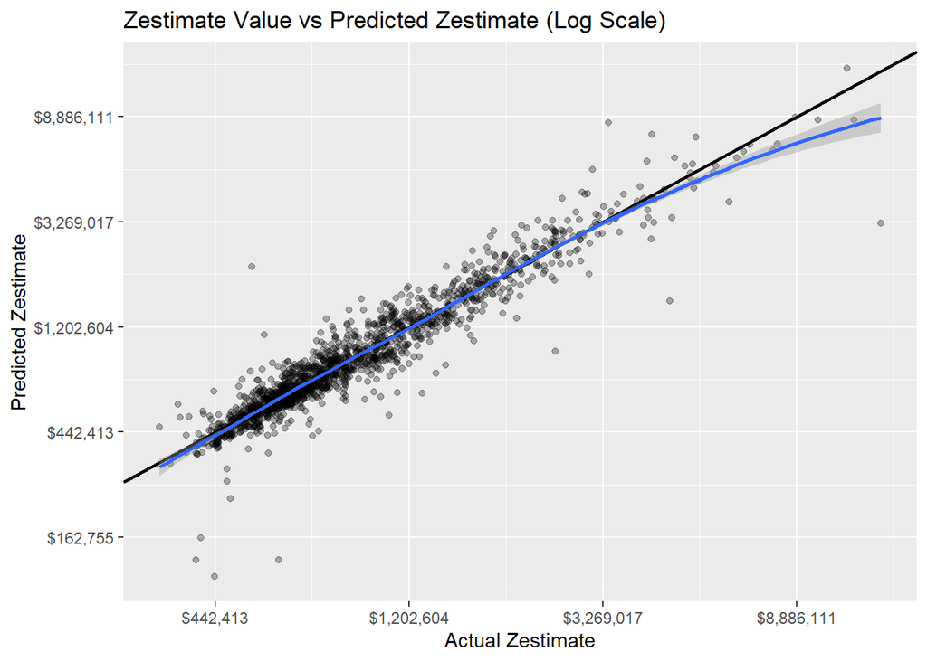